# Ticket Predictor con IA: prioriza clientes por monto esperado

Author

BI Evolution

## Resumen ejecutivo

Este análisis construye un **Ticket Predictor**:  
un modelo de IA que estima el **monto de la próxima compra** de cada cliente.

Con este modelo se puede:

- Estimar cuánto podría gastar cada cliente en su siguiente visita.
- Ordenar la base según **ticket esperado**.
- Comparar el **ROI** de:
  1. Llamar a 500 clientes **al azar**.
  2. Llamar a 500 clientes con **mayor ticket esperado** según el modelo.

El objetivo es mostrar, en términos económicos, cómo un modelo de IA permite usar la **misma capacidad comercial** (500 llamadas),  
pero generando **más ventas en soles**.

## 1. Datos simulados de clientes

A continuación se simulan **5,000 clientes** con variables típicas de negocio:

- `segmento_cliente` (Alta frecuencia / Media / Ocasional)
- `frecuencia_anual` (número de compras en el año)
- `ticket_promedio_historico` (S/.)
- `dias_ultima_compra`
- `canal_favorito` (Tienda / Online / WhatsApp)
- `uso_cupones` (Sí / No)
- `nivel_satisfaccion` (1 a 5)
- `descuento_promedio` (%)
- `num_categorias` (diversidad de productos)
- `ticket_real_proxima_compra` (variable objetivo a predecir)

## 2. Entrenamiento del modelo de Ticket Predictor

Se usa un enfoque de regresión para predecir `ticket_real_proxima_compra` a partir de las demás variables.

Se evalúan varios modelos:

- Regresión lineal
- Random Forest
- XGBoost

Y se selecciona el de **mejor desempeño (menor RMSE)** según validación cruzada.

> **Lectura rápida:** El modelo seleccionado es **Regresión lineal**, por ser el que logra **menor error (RMSE medio)** al predecir el ticket de la próxima compra.

## 3. Desempeño del modelo en el set de prueba

Se evalúa el modelo sobre datos **no vistos en entrenamiento**.

Métricas de desempeño del Ticket Predictor en el set de prueba

| Métrica | Valor |
| --- | --- |
| RMSE (set de prueba) | 55.996 |
| MAE (set de prueba) | 45.629 |
| R² (set de prueba) | 0.554 |

### 3.1. Relación entre ticket real y ticket predicho

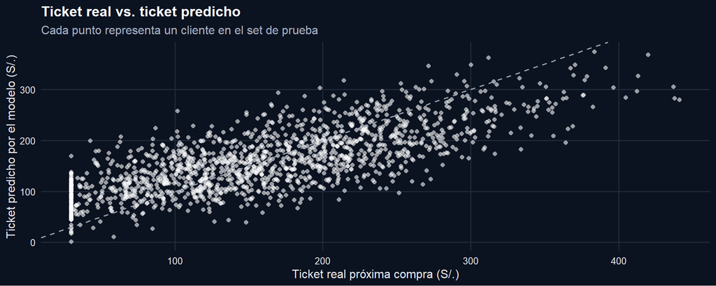

## 4. ROI: 500 llamadas al azar vs. 500 llamadas guiadas por IA

Se comparan dos estrategias con la **misma capacidad comercial (500 llamadas)**:

- **Sin modelo:** 500 llamadas al azar → el ROI depende del ticket real de esos 500.
- **Con modelo IA:** 500 llamadas a quienes el modelo estima con **mayor ticket esperado**.

### Supuestos de negocio

- Solo se contabiliza la **venta de la próxima compra** (sin CLV todavía).
- Cada llamada tiene un **costo operativo** (tiempo, canal, etc.): **S/ 4 por llamada**.
- El ROI total del escenario se calcula como la suma del margen generado por cada cliente contactado:

$$\text{ROI} = \sum_{i \in \text{contactados}} \big( \text{ticket\_real}_i - \text{costo\_llamada} \big)$$

donde:

- $\text{ticket\_real}_i$ es el monto efectivamente comprado por el cliente $i$.
- $\text{costo\_llamada}$ es el costo fijo de contactar a cada cliente (S/. 4 en este ejemplo).

El modelo **no llama más**, sino que **prioriza mejor**: usa las mismas 500 llamadas para contactar a los clientes que generan más ingresos.

Comparación de ROI: estrategia al azar vs. estrategia guiada por IA

| Escenario | ROI estimado (S/.) |
| --- | --- |
| Sin modelo (500 llamadas al azar) | 79161 |
| Con modelo IA (500 mayores tickets esperados) | 115202 |

> **Lectura rápida:** Con los mismos 500 contactos:
> - Sin modelo se obtiene un ROI estimado de **S/. 79,160.6**.
> - Con el Ticket Predictor, el ROI sube a **S/. 115,202**.
> - Esto representa una mejora aproximada de **45.5%** en la campaña, solo por **elegir mejor a quién llamar**.

### 4.1. Comparativa visual del ROI

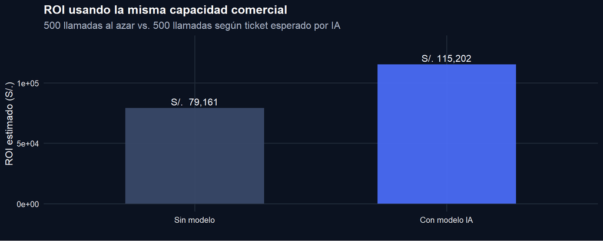

### 4.2. ¿Cómo se eligen los 500 clientes priorizados?

En la estrategia **Con modelo IA**, la selección de clientes sigue una lógica muy clara:

1. El modelo predice el **ticket esperado de la próxima compra** para cada cliente (`pred_ticket`).
2. Se ordena a todos los clientes **de mayor a menor** según ese ticket esperado.
3. Se eligen los **500 primeros** de ese ranking, es decir, los 500 clientes con **mayor valor esperado en soles**.

Esto permite usar la misma capacidad comercial (500 llamadas), pero dirigiéndola hacia quienes tienen **más potencial de venta**.

Top 10 clientes priorizados por mayor ticket esperado (según IA)

| id_cliente | segmento_cliente | frecuencia_anual | ticket_promedio_historico | dias_ultima_compra | canal_favorito | uso_cupones | nivel_satisfaccion | descuento_promedio | num_categorias | ticket_real_proxima_compra | ticket_predicho |
| --- | --- | --- | --- | --- | --- | --- | --- | --- | --- | --- | --- |
| 2890 | Alta frecuencia | 19 | 265.2 | 158 | Tienda | 1 | 5 | 12.5 | 5 | 383.6 | 374.06 |
| 106 | Alta frecuencia | 18 | 213.9 | 61 | WhatsApp | 0 | 5 | 4.3 | 4 | 420.0 | 367.85 |
| 3247 | Alta frecuencia | 19 | 194.2 | 97 | Tienda | 1 | 5 | 5.8 | 6 | 312.2 | 362.13 |
| 3196 | Alta frecuencia | 20 | 175.7 | 48 | WhatsApp | 1 | 5 | 7.8 | 4 | 370.7 | 348.68 |
| 2907 | Alta frecuencia | 14 | 254.0 | 40 | WhatsApp | 0 | 4 | 9.0 | 5 | 300.3 | 348.00 |
| 4360 | Alta frecuencia | 17 | 177.0 | 94 | Tienda | 0 | 5 | 1.8 | 5 | 271.5 | 346.50 |
| 734 | Alta frecuencia | 14 | 260.7 | 226 | Tienda | 0 | 5 | 6.3 | 5 | 391.2 | 342.70 |
| 1563 | Alta frecuencia | 15 | 246.8 | 123 | Tienda | 0 | 4 | 5.2 | 4 | 367.6 | 341.78 |
| 3035 | Alta frecuencia | 22 | 135.6 | 25 | Tienda | 0 | 3 | 3.2 | 3 | 290.7 | 329.63 |
| 637 | Alta frecuencia | 14 | 251.9 | 185 | WhatsApp | 0 | 5 | 7.5 | 3 | 369.5 | 327.87 |

## 5. Cómo se usa esto en negocio

En términos simples:

1. A cada cliente se le asigna un **ticket esperado** para su próxima compra.
2. Se ordena la base de mayor a menor ticket esperado.
3. El equipo comercial:
   - Llama primero a los clientes con **mayor valor esperado**.
   - Deja al resto para **campañas masivas** o de bajo esfuerzo.